# EDA of Alcohol Consumption among Students

Ilia Ozhmegov, Olena Horyn

July 2020

The data were obtained in a survey of students math and Portuguese language courses in secondary school. It contains a lot of interesting social, gender and study information about students.

# 1 Student Data

In Portugal, the secondary education consists of 3 years of schooling, preceding 9 years of basic education and followed by higher education. Most of the students join the public and free education system. There are several courses (e.g. Sciences and Technologies, Visual Arts) that share core subjects such as the Portuguese Language and Mathematics. Like several other countries (e.g. France or Venezuela), a 20-point grading scale is used, where 0 is the lowest grade and 20 is the perfect score. During the school year, students are evaluated in three periods and the last evaluation (G3 of Table 1) corresponds to the final grade.

This study will consider data collected during the 2005- 2006 school year from two public schools, from the Alentejo region of Portugal. Although there has been a trend for an increase of Information Technology investment from the Government, the majority of the Portuguese public school information systems are very poor, relying mostly on paper sheets (which was the current case). Hence, the database was built from two sources: school reports, based on paper sheets and including few attributes (i.e. the three period grades and number of school absences); and questionnaires, used to complement the previous information. Original researches designed the latter with closed questions (i.e. with predefined options) related to several demographic (e.g. mother’s education, family income), social/emotional (e.g. alcohol consumption) (Pritchard and Wilson 2003) and school related (e.g. number of past class failures) variables that were expected to affect student performance. The questionnaire was reviewed by school professionals and tested on a small set of 15 students in order to get a feedback. The final version contained 37 questions in a single A4 sheet and it was answered in class by 788 students. Latter, 111 answers were discarded due to lack of identification details (necessary for merging with the school reports). Finally, the data was integrated into two datasets related to Mathematics (with 395 examples) and the Portuguese language (649 records) classes.

During the original preprocessing stage, some features were discarded due to the lack of discriminative value. For instance, few respondents answered about their family income (probably due to privacy issues), while almost 100% of the students live with their parents and have a personal computer at home. The remaining attributes are shown in Table 1, where the last four rows denote the variables taken from the school reports.

Table 1: data after all the preprocessing stages

[output not shown]

The labeled with `*` attributes were added during the current research.

# 2 Main Goals

- to find what affects on success the most significantly
- to find what affects on alcohol consumption the most significantly

# 3 Brief introduction into alcohol consumption

Let us have a look at alcohol consumption and compare it during weekday and weekend.

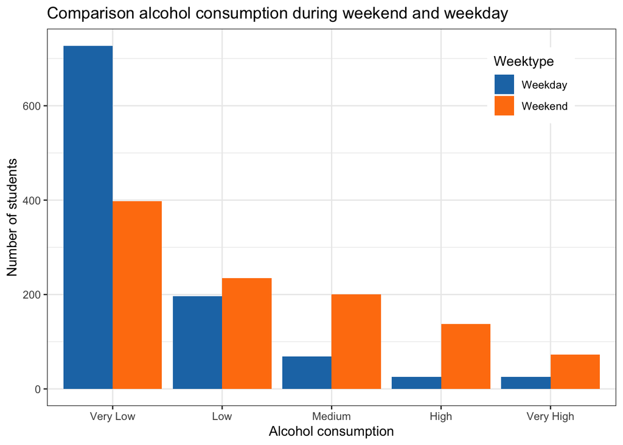

```r
  reshape2::melt(full_df[,c('Dalc','Walc')],id.vars = 0) %>%
    group_by(variable, value) %>%
    summarise(n=n()) %>%
    mutate(
      value = factor(value, levels = c("Very Low", "Low", "Medium", "High", "Very High"))
    ) %>%
    ggplot(aes(x=value, y=n)) +
    geom_bar(aes(fill = variable),stat = "identity", position = "dodge") +
    theme_bw() +
    scale_fill_manual(values = matlab.colors[1:2],
                      name   = "Weektype",
                      labels = c("Weekday", "Weekend")) +
    theme(legend.position = c(0.85, 0.85), legend.box = "vertical") +
    labs(y = "Number of students",
         x = "Alcohol consumption",
         title = "Comparison alcohol consumption during weekend and weekday")
```

The result is clear, during weekend consumption is higher than during weekdays.

# 4 What affects the most on success

Though basically we have categorical data we still want to have a look at correlation between final grade and all others variables

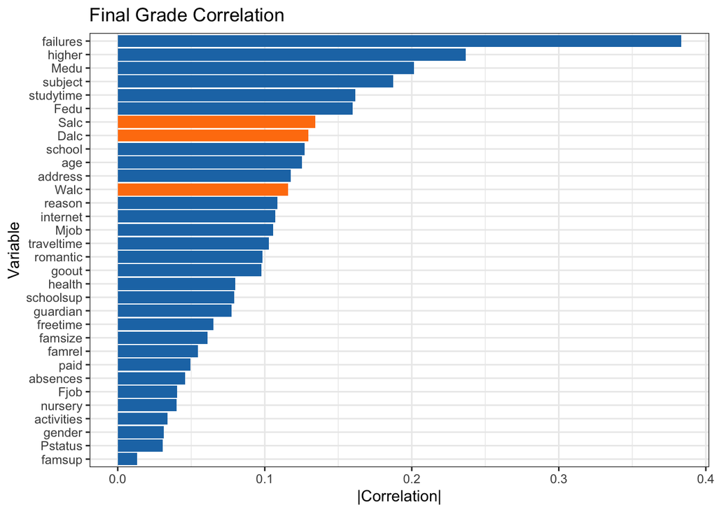

```r
{
  int_df <- lapply(full_df, as.integer)
  n = length(int_df)

  c = rep(0, n)
  for(i in 1:n) c[i] = cor(int_df$G3, int_df[[i]]) %>% abs()

  data.frame(correlation = c, name = colnames(full_df))  %>%
    filter(!str_detect(name, "^G")) %>%
    ggplot(aes(x = correlation, y = reorder(name, correlation))) +
    geom_bar(stat = "identity", aes(fill = str_detect(name, "alc$"))) +
    scale_fill_manual(values = matlab.colors[1:2]) +
    theme_bw() +
    theme(legend.position="none") +
    labs(y = "Variable", x = "|Correlation|", title = "Final Grade Correlation")

}
```

Result: in general there is a poor dependence between variables and final grade, but it is important to remind that all variable are categorical, but `failures` and `absences` (`failures` is not fully continuous). Also, we highlighted the alcohol consumption variables to show that there is no clear linear dependence.

## 4.1 Closer look at dependence between Grades and alcohol consumption

Simple presentation of grades before diving deeper to show the quantity of the students divided into different success groups.

We will consider as successful only students with grades from “C” to “A” and as unsuccessful with grades “F” and “D”. As Portuguese educational system uses numeric marks from 0 to 20, we need to transform it into the five-level classification system.

| Original | 5-level |
| --- | --- |
| [16,20] | A |
| [14,16) | B |
| [12,14) | C |
| [10,12) | D |
| [0, 10) | F |

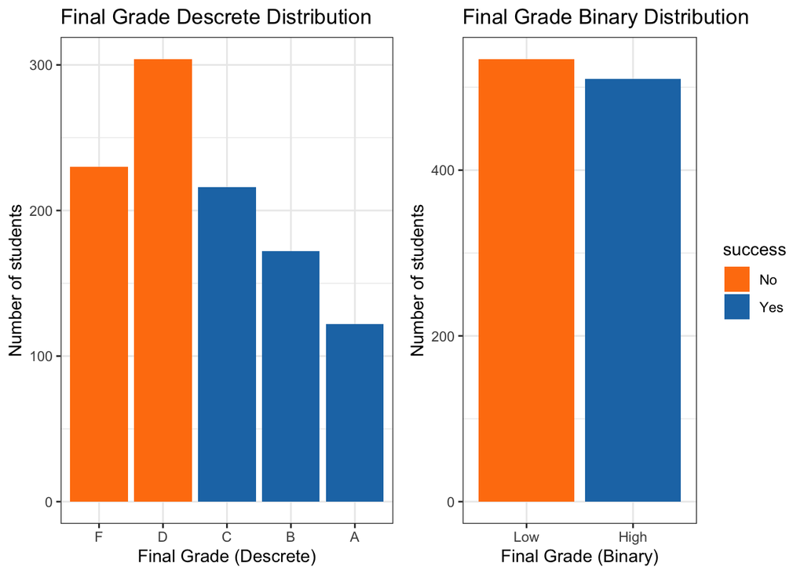

```r
{  ddf <- full_df %>%
    mutate(
      success = ifelse(G3_d == 'F' | G3_d == 'D', 'No', 'Yes'),
      G3_d = factor(G3_d, levels = c('F', 'D', 'C', 'B', 'A'))
      )

  p1 <- ddf %>%
    ggplot(aes(x=G3_d, fill=success)) +
    geom_bar(position = "dodge") +
    theme_bw() +
    theme(legend.position="none") +
    scale_fill_manual(values=matlab.colors[2:1]) +
    labs(y = "Number of students",
         x = "Final Grade (Descrete)",
         title = "Final Grade Descrete Distribution")

  p2 <- ddf %>%
    ggplot(aes(x=success, fill=success)) +
    geom_bar(position = "dodge") +
    scale_fill_manual(values=matlab.colors[2:1]) +
    theme_bw() +
    scale_x_discrete(breaks=c("No","Yes"),
                     labels=c("Low", "High")) +
    labs(y = "Number of students",
         x = "Final Grade (Binary)",
         title = "Final Grade Binary Distribution")

  grid.arrange(p1, p2, nrow=1)


}
```

As you can seen the amount of students in both groups is almost the same.

Let us have a look directly at dependence between Grades and Alcohol consumption.

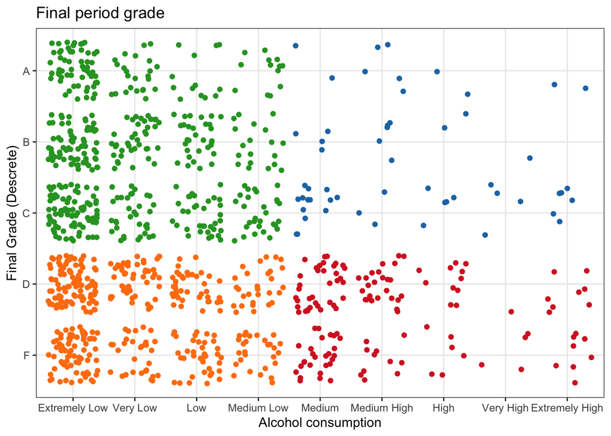

```r
{

  class_df = full_df %>%
    mutate(
      s_class = ifelse(G3 < 12, 1, 2),
      s_class = s_class + ifelse(as.numeric(Salc) < 5, 0, 2),
      G3_d = factor(G3_d, levels = c('F', 'D', 'C', 'B', 'A'))
      )

  class_df %>%
    ggplot(aes(x=Salc, G3_d)) +
    geom_jitter(aes(colour = as.factor(s_class))) +
    scale_color_manual(values=matlab.colors[c(2, 3, 4, 1)]) +
    theme_bw() +
    theme(legend.position="none") +
    labs(y = "Final Grade (Descrete)",
         x = "Alcohol consumption",
         title = "Final period grade")

}
```

Result: decent grades are much less frequent among high alcohol consumption Students, also there is no dependence between low alcohol consumption and decent grades. The last point can be seen more vividly in the following figure.

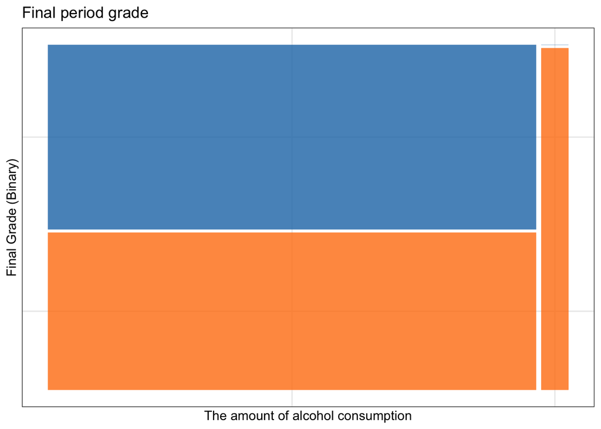

```r
  class_df %>%
    mutate(
      failure   = ifelse( s_class %% 2 == 1, 'High', 'Low'),
      addiction = ifelse( s_class > 3, 'High', 'Low'),
      failure   = factor(failure,   levels = c('Low', 'High')),
      addiction = factor(addiction, levels = c('Low', 'High'))
    ) %>%
    ggplot() +
    geom_mosaic(aes(x=product(failure, addiction), fill=failure), na.rm = TRUE) +
    scale_fill_manual(values=matlab.colors[2:1]) +
    theme_bw() +
    theme(legend.position="none") +
    labs(x = "The amount of alcohol consumption",
         y = "Final Grade (Binary)",
         title = "Final period grade")
```

## 4.2 Dependence between Grades and such variables as gender and age

How does age and gender affect on success?

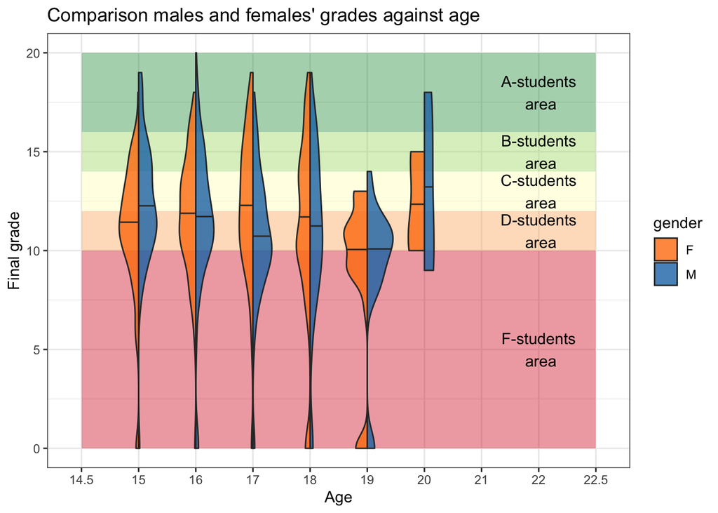

```r
{

  age_min = (full_df$age - 0.5) %>% min() %>% as.factor()
  age_max = (full_df$age + 0.5) %>% max() %>% as.factor()

  common_alpha = 0.4

  full_df %>%
    ggplot() +
    annotate("rect",
             xmin = age_min, xmax = age_max,
             ymin = 0,  ymax = 10, fill = colours_5[[5]],
             alpha = common_alpha
    ) +
    annotate("rect",
             xmin = age_min, xmax = age_max,
             ymin = 10, ymax = 12, fill = colours_5[[4]],
             alpha = common_alpha
    ) +
    annotate("rect",
             xmin = age_min, xmax = age_max,
             ymin = 12, ymax = 14, fill = colours_5[[3]],
             alpha = common_alpha
    ) +
    annotate("rect",
             xmin = age_min, xmax = age_max,
             ymin = 14, ymax = 16, fill = colours_5[[2]],
             alpha = common_alpha
    ) +
    annotate("rect",
             xmin = age_min, xmax = age_max,
             ymin = 16, ymax = 20, fill = colours_5[[1]],
             alpha = common_alpha
    ) +
    geom_split_violin(aes(x=age %>% as.factor(),  y=G3, fill=gender),
                      draw_quantiles = c(0.5)) +
    scale_fill_manual(values=alpha(matlab.colors[2:1], 0.8)) +
    theme_bw() +
    annotate("text", x = "22", y = 5,  label = "F-students\n area") +
    annotate("text", x = "22", y = 11, label = "D-students\n area") +
    annotate("text", x = "22", y = 13, label = "C-students\n area") +
    annotate("text", x = "22", y = 15, label = "B-students\n area") +
    annotate("text", x = "22", y = 18, label = "A-students\n area") +
    labs(x = "Age",
         y = "Final grade",
         title = "Comparison males and females' grades against age")

}
```

Result: the majority of students are in C and D areas, besides there is no difference between males and females, but after the age of 18 the distribution is completely different and we do not have a solid explanation for that.

# 5 Exploration of possible effects on students’ alcohol consumption

In this section we explore possible factors that could be linked to the level of alcohol consumption among portugese students. We will take a look at the students’ gender, the Area where they live, their family size and student’s leisure time, and see if any of these change depending on the part of the week - whether it’s a regular weekday or a weekend.

## 5.1 The role of gender and age in students’ alcohol consumption

First, we wanted to find out whether a gender plays a role in a level of students’ alcohol consumption, by taking age and time of the week into account.

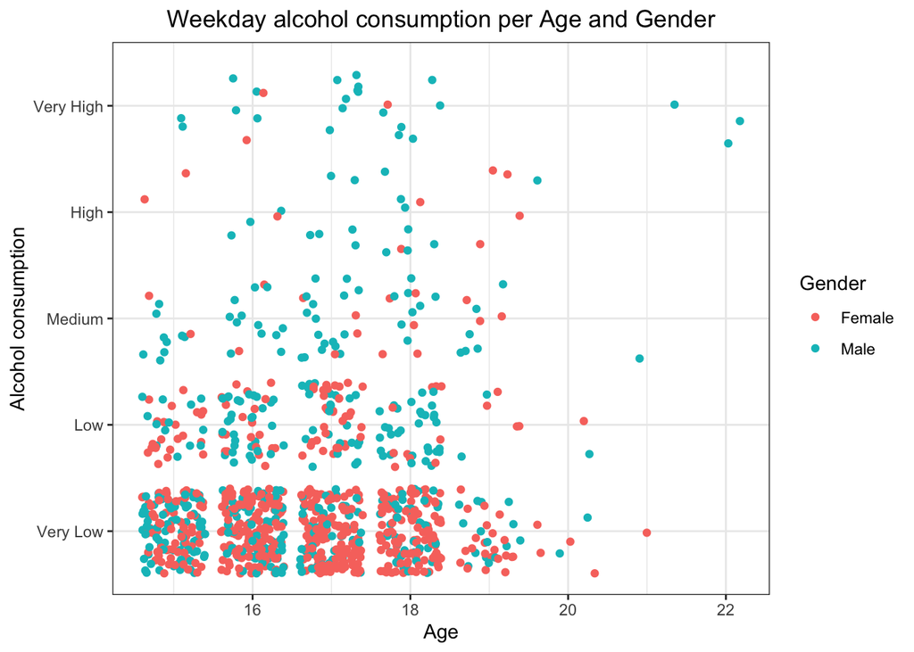

```r
{

  p1 <- full_df %>%
ggplot(aes(x=age, y=Dalc, color=gender))+
  geom_jitter()+
  scale_colour_manual(values=c("#F8766D", "#00BFC4"),
                      name="Gender",
                      labels=c("Female", "Male"))+
  theme_bw()+
  xlab("Age")+
  ylab("Alcohol consumption")+
  ggtitle("Weekday alcohol consumption per Age and Gender")+
  theme(plot.title = element_text(hjust = 0.5))
p1

}
```

Result: we can observe that quite a few males of all given ages consume larger levels of alcohol during the week. And females have a tendency to stay away from alcohol on the weekdays.

This is how it changes during the weekend.

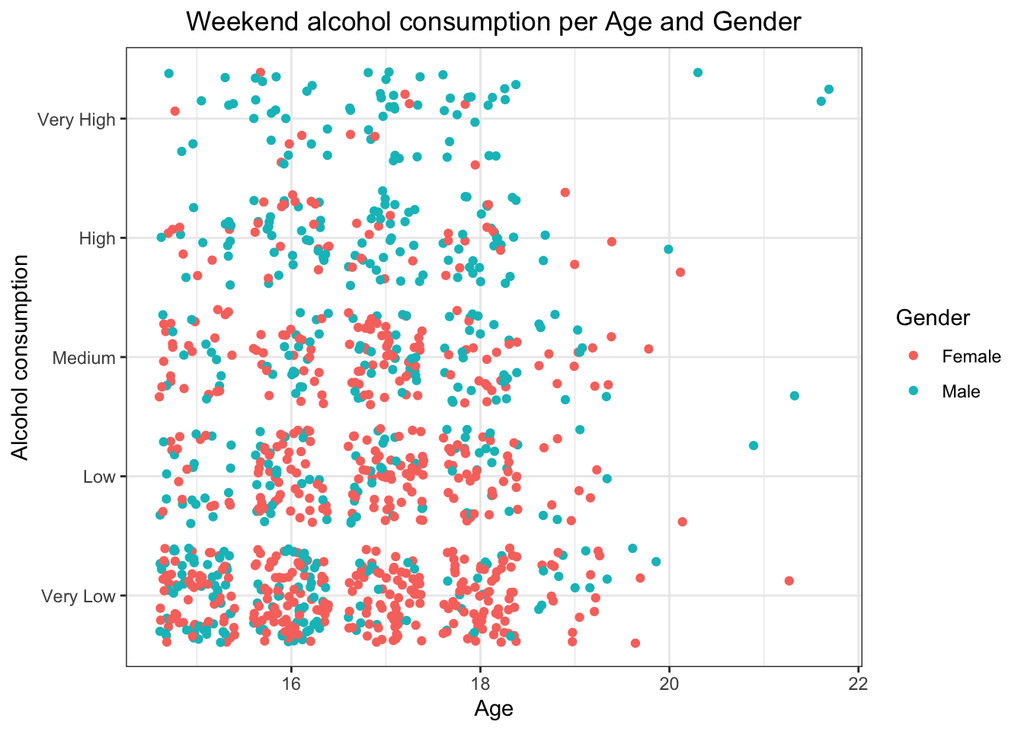

```r
{

p2 <- full_df %>%
ggplot(aes(x=age, y=Walc, color=gender))+
  geom_jitter()+
  scale_colour_manual(values=c("#F8766D", "#00BFC4"),
                      name="Gender",
                      labels=c("Female", "Male"))+
  theme_bw()+
  xlab("Age")+
  ylab("Alcohol consumption")+
  ggtitle("Weekend alcohol consumption per Age and Gender")+
  theme(plot.title = element_text(hjust = 0.5))
p2

}
```

Result: as can be seen from the above plot, some more females start to drink a little more on the weekends. As well as some more males, regardless of the age. Age doesn’t really play a role in students’ alcohol consumption levels. But the gender does. And again, the time of the week is a significant factor - there is a clear evidence that more students consume higher levels of alcohol on the weekends.

## 5.2 Exploration of students’ background and alcohol consumption

Let’s explore if the area where students reside impacts their alcohol consumption. Students were categorized by address: Urban and Rural.

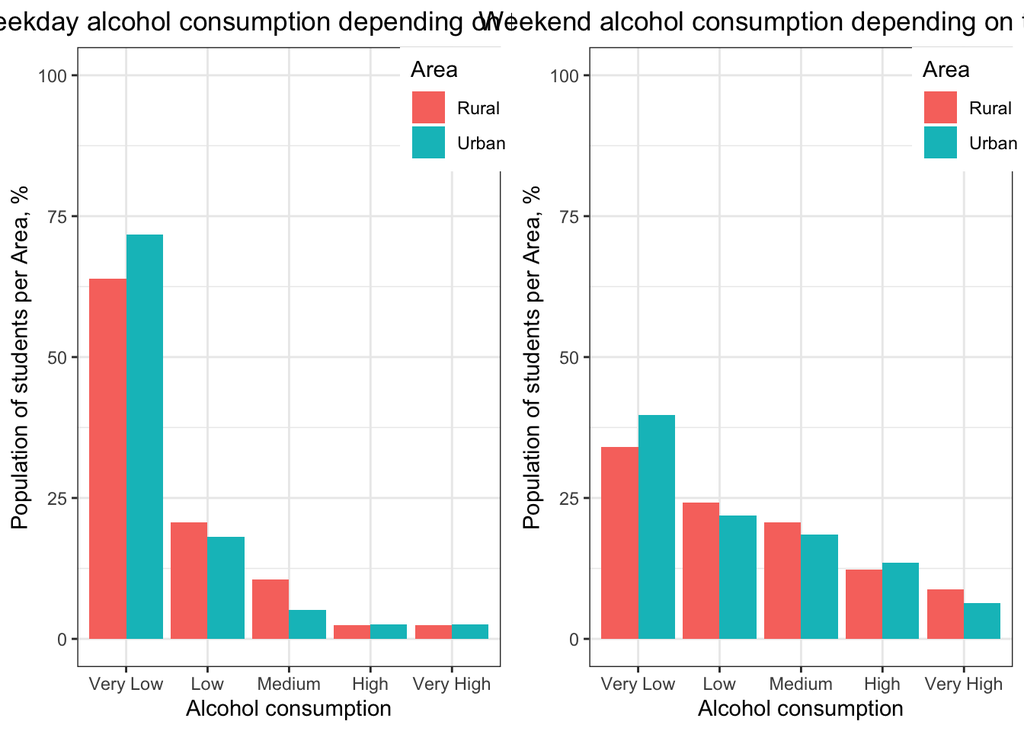

```r
{

# Daily alcohol consumption
p3 <- full_df %>%
  group_by(address, Dalc) %>%
  summarise(count=n()) %>%
  mutate(perc=count/sum(count)) %>%
  ggplot(aes(x=factor(Dalc), y = perc*100, fill=address))+
  geom_bar(stat = "identity", position = "dodge")+
  ylim(0,100)+
  scale_fill_manual(values=c("#F8766D", "#00BFC4"),
                    labels = c('Rural', 'Urban'))+
  labs(fill = "Area")+
  theme_bw()+
  xlab("Alcohol consumption")+
  ylab("Population of students per Area, %")+
  ggtitle("Weekday alcohol consumption depending on the Area")+
  theme(legend.position = c(0.9, 0.9), legend.box = "vertical") +
  theme(plot.title = element_text(hjust = 0.5))

# Weekend alcohol consumption
p4 <- full_df %>%
  group_by(address, Walc) %>%
  summarise(count=n()) %>%
  mutate(perc=count/sum(count)) %>%
  ggplot(aes(x=factor(Walc), y = perc*100, fill=address))+
  geom_bar(stat = "identity", position = "dodge")+
  ylim(0,100)+
  scale_fill_manual(values=c("#F8766D", "#00BFC4"),
                    labels = c('Rural', 'Urban'))+
  labs(fill = "Area")+
  theme_bw()+
  xlab("Alcohol consumption")+
  ylab("Population of students per Area, %")+
  ggtitle("Weekend alcohol consumption depending on the Area")+
  theme(legend.position = c(0.9, 0.9), legend.box = "vertical") +
  theme(plot.title = element_text(hjust = 0.5))

# Arrange plots side-by-side
grid.arrange(p3, p4, ncol=2)

}
```

Result: this figure shows that when it comes to moderate amounts of alcohol consumption, the percentage of students in rural areas tend to drink slightly more than students from urban areas. And this is for both times of the week: weekdays and weekends.

Next, let’s explore the students’ family sizes. Again, students were split into two groups: students of large families of more than 3 family members and of the smaller families of 3 or less people.

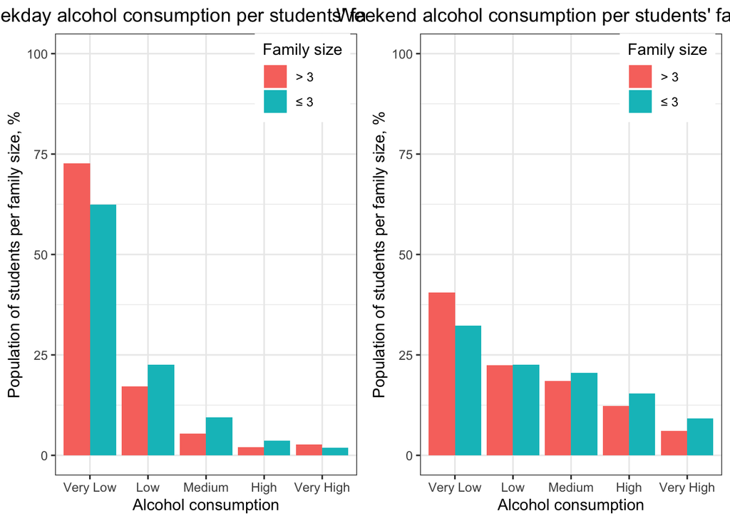

```r
{

# Daily alcohol consumption
p5 <- full_df %>%
  group_by(famsize, Dalc) %>%
  summarise(count=n()) %>%
  mutate(perc=count/sum(count)) %>%
  ggplot(aes(x=factor(Dalc), y = perc*100, fill=famsize))+
  geom_bar(stat = "identity", position = "dodge")+
  ylim(0,100)+
  scale_fill_manual(values=c("#F8766D", "#00BFC4"),
                    labels = c('> 3', '≤ 3'))+
  labs(fill = "Family size")+
  theme_bw()+
  xlab("Alcohol consumption")+
  ylab("Population of students per family size, %")+
  ggtitle("Weekday alcohol consumption per students' family size")+
  theme(legend.position = c(0.82, 0.9), legend.box = "vertical") +
  theme(plot.title = element_text(hjust = 0.5))

# Weekend alcohol consumption
p6 <- full_df %>%
  group_by(famsize, Walc) %>%
  summarise(count=n()) %>%
  mutate(perc=count/sum(count)) %>%
  ggplot(aes(x=factor(Walc), y = perc*100, fill=famsize))+
  geom_bar(stat = "identity", position = "dodge")+
  ylim(0,100)+
  scale_fill_manual(values=c("#F8766D", "#00BFC4"),
                    labels = c('> 3', '≤ 3'))+
  labs(fill = "Family size")+
  theme_bw()+
  xlab("Alcohol consumption")+
  ylab("Population of students per family size, %")+
  ggtitle("Weekend alcohol consumption per students' family size")+
  theme(legend.position = c(0.82, 0.9), legend.box = "vertical") +
  theme(plot.title = element_text(hjust = 0.5))

# Arrange plots side-by-side
grid.arrange(p5, p6, ncol=2)

}
```

Result: students from smaller families consume a bit higher levels of alcohol, especially on the weekends.

## 5.3 The effect of students’ leisure time on alcohol consumption

In this subsection we take a closer look at students’ free time and the time when they go out, and how it affects their alcohol consumption.

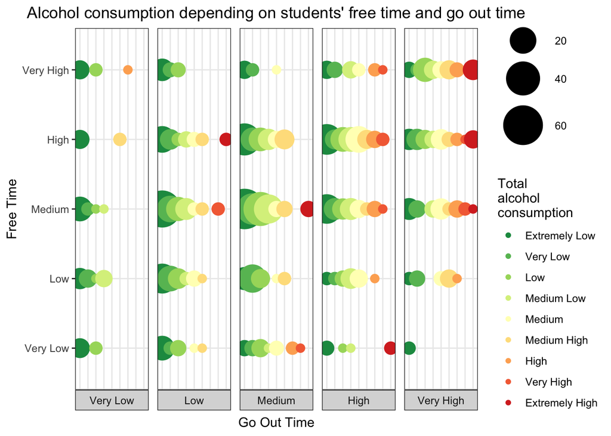

```r
{

p7 <- full_df %>%
  ggplot(aes(y=freetime, x=Salc, color=Salc, group=freetime)) +
  geom_count() +
  scale_size(range = c(3, 15)) +
  scale_color_manual(values=colours_9,
                     name="Total \nalcohol \nconsumption") +
  theme_bw() +
  theme(axis.text.x = element_blank(),
        axis.ticks.x = element_blank(),
        panel.spacing.x=unit(0.5, "lines")) +
  facet_grid(. ~ goout, switch="both") +
  labs(x = "Goout",
       size = "")+
  xlab("Go Out Time")+
  ylab("Free Time")+
  ggtitle("Alcohol consumption depending on students' free time and go out time")+
  theme(plot.title = element_text(hjust = 0.5))
p7

}
```

Result: we can observe a general trend that the more free time students have and the more they go out, the more alcohol they tend to consume.

Let’s explore this in more detail, by looking separately at students’ free time, go out time and part of the week (weekday or weekend).

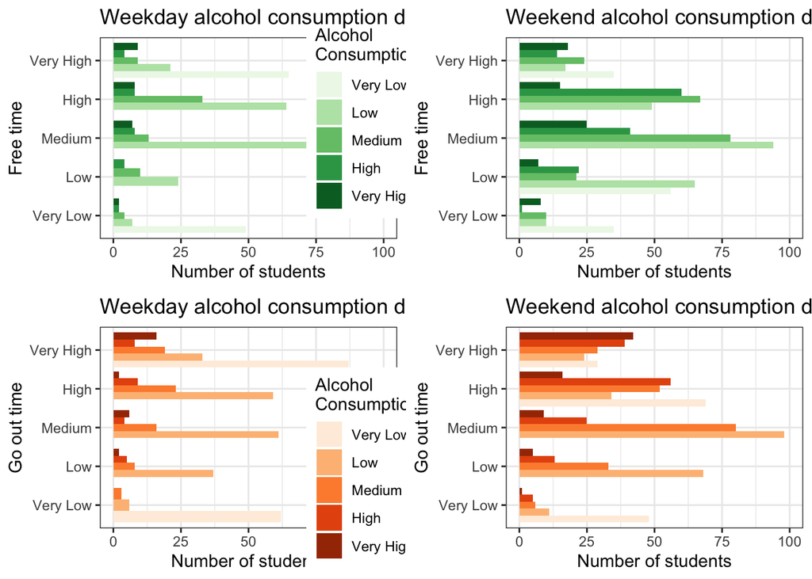

```r
{

# Free time during weekdays
p8 <- full_df %>%
  group_by(freetime, Dalc) %>%
  summarise(count=n()) %>%
  mutate(count=count) %>%
  ggplot(aes(x=factor(freetime), y = count, fill=Dalc))+
  geom_bar(stat = "identity", position = "dodge")+
  ylim(0,100)+
  scale_fill_brewer(palette="Greens")+
  coord_flip()+
  theme_bw()+
  xlab("Free time")+
  ylab("Number of students")+
  labs(fill = "Alcohol \nConsumption")+
  ggtitle("Weekday alcohol consumption depending on students' free time") +
  theme(legend.position = c(0.9, 0.6),
        legend.box = "vertical")

# Free time on the weekends
p9 <- full_df %>%
  group_by(freetime, Walc) %>%
  summarise(count=n()) %>%
  mutate(count=count) %>%
  ggplot(aes(x=factor(freetime), y = count, fill=Walc))+
  geom_bar(stat = "identity", position = "dodge")+
  ylim(0,100)+
  scale_fill_brewer(palette="Greens")+
  coord_flip()+
  theme_bw()+
  xlab("Free time")+
  ylab("Number of students")+
  labs(fill = "Alcohol \nConsumption")+
  ggtitle("Weekend alcohol consumption depending on students' free time") +
  theme(legend.position="none")

# Go out time during weekdays
p10 <- full_df %>%
  group_by(goout, Dalc) %>%
  summarise(count=n()) %>%
  mutate(count=count) %>%
  ggplot(aes(x=factor(goout), y = count, fill=Dalc))+
  geom_bar(stat = "identity", position = "dodge")+
  ylim(0,100)+
  scale_fill_brewer(palette="Oranges")+
  coord_flip()+
  theme_bw()+
  xlab("Go out time")+
  ylab("Number of students")+
  labs(fill = "Alcohol \nConsumption")+
  ggtitle("Weekday alcohol consumption depending students' go out time") +
  theme(legend.position = c(0.9, 0.3),
        legend.box = "vertical")

# Go out time on the weekends
p11 <- full_df %>%
  group_by(goout, Walc) %>%
  summarise(count=n()) %>%
  mutate(count=count) %>%
  ggplot(aes(x=factor(goout), y = count, fill=Walc))+
  geom_bar(stat = "identity", position = "dodge")+
  ylim(0,100)+
  scale_fill_brewer(palette="Oranges")+
  coord_flip()+
  theme_bw()+
  xlab("Go out time")+
  ylab("Number of students")+
  labs(fill = "Alcohol \nConsumption")+
  ggtitle("Weekend alcohol consumption depending students' go out time") +
  theme(legend.position="none")

# Arrange plots
grid.arrange(p8, p9, p10, p11, nrow=2, ncol=2)

}
```

## 5.4 The relationship between alcohol consumption and final grades by gender

Let’s take another look at the students’ final grades and the level of their alcohol consumption by gender and time of the week.

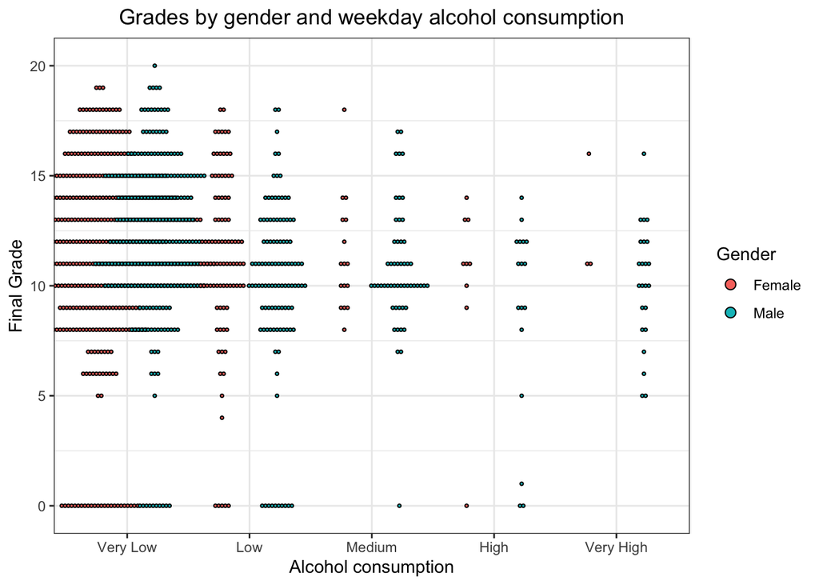

```r
{

p12 <- full_df %>%
  ggplot(aes(x=Dalc %>% as.factor(),  y=G3, fill=gender)) +
  geom_dotplot(binaxis = "y",
               stackdir = "center",
               position = "dodge",
               dotsize = 0.3, binwidth = 0.5)+
  theme_bw()+
  labs(fill = "Gender")+
  scale_fill_manual(values=c("#F8766D", "#00BFC4"),
                    labels = c('Female', 'Male'))+
  xlab("Alcohol consumption")+
  ylab("Final Grade")+
  ggtitle("Grades by gender and weekday alcohol consumption")+
  theme(plot.title = element_text(hjust = 0.5))
p12

}
```

Result: both males and females tend to have better grades when they don’t consume much alcohol during the week. Although, as was explored in part 4.1, we can’t make a clear connection between low alcohol consumption and good grades. However, we observe that some males consume larger amounts of alcohol while having average and below average grades.

Weekend alcohol consumption and final grades by gender.

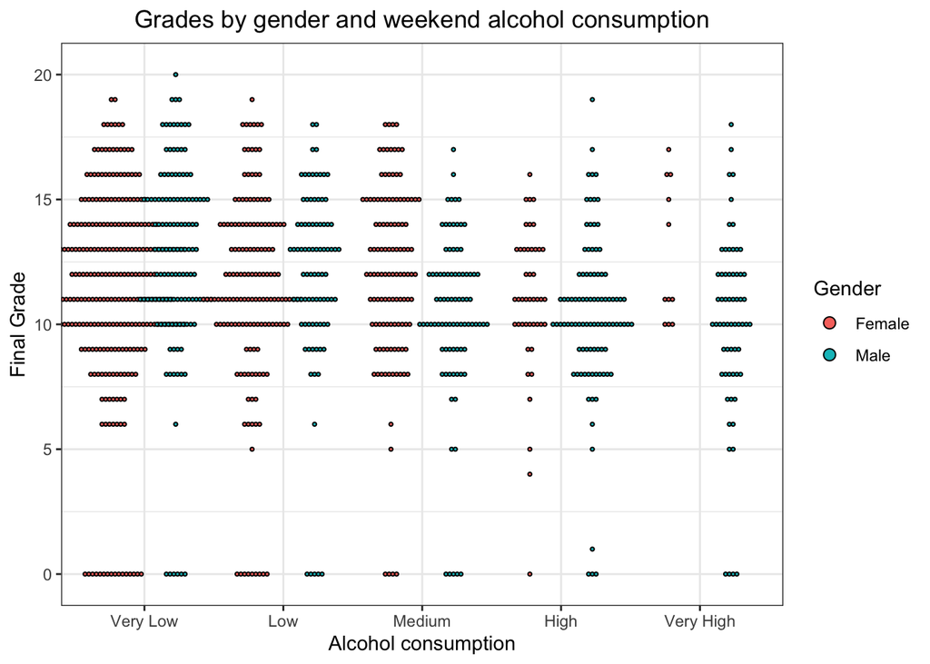

```r
{

p13 <- full_df %>%
  ggplot(aes(x=Walc %>% as.factor(),  y=G3, fill=gender)) +
  geom_dotplot(binaxis = "y",
               stackdir = "center",
               position = "dodge",
               dotsize = 0.3, binwidth = 0.5)+
  theme_bw()+
  labs(fill = "Gender")+
  scale_fill_manual(values=c("#F8766D", "#00BFC4"),
                    labels = c('Female', 'Male'))+
  xlab("Alcohol consumption")+
  ylab("Final Grade")+
  ggtitle("Grades by gender and weekend alcohol consumption")+
  theme(plot.title = element_text(hjust = 0.5))
p13

}
```

Result: weekend alcohol consumption doesn’t seem to have a significant effect on students’ grades. This time, more of both genders increase their alcohol consumption.

# 6 Conclusion

The aim of this exploratory data analysis was to find out what has the most significant effect on students’ success and to explore the possible effects on students’ alcohol consumption.

The first part of this project focused on students’ grades as the measure of their success in the school. We saw that there is a weak correlation between final grades and alcohol consumption. We can conclude that alcohol consumption has an effect on students’ success only to some very limited degree. It’s important to note that correlation does not mean a causation.

We also explored that part of the week plays a very important role when it comes to the level of students’ alcohol consumption. We saw this in every part of our analysis, that students consume higher levels of alcohol on the weekends. Students of both genders had about the same grades on average. So male and female students in our dataset were equally successful in school in terms of grades. Age didn’t seem to play a significant role as well.

In the second part of our analysis, we explored possible factors that could affect students’ alcohol consumption. We found out that students’ gender, their family size and area where they live could potentially affect the level of students’ alcohol consumption, but we didn’t see a big impact.

Our research showed that female students tend to consume lower amounts of alcohol compared to their fellow male students, especially during the week. Also we explored that there is a slight relationship between the students’ background, particularly the area where they live and their family size, and the amount of alcohol they consume. And our analysis showed that when students have free time and especially when they go out - they increase their alcohol consumption. This effect can be clearly observed on the weekends.

We can conclude that our exploratory data analysis was successful. We have answered the questions that we asked ourselves at the beginning of the research.

We also have learned a lot while working on this project:

- use R packages such as: ggplot2, magrittr, dplyr and tidyverse
- create plots with more than 2 variables
- how to work with only nominal/discrete variables
- create violin plots, mosaic plots, jitter plots and others
- work remotely as a team
- build a research pipeline with github
- create an html/pdf reports

We have faced some challenges as well. In particular, working remotely as a team was a learning curve. We faced some timing, technical and organizational issues that we have successfully overcome.

Overall, this was a challenging and yet very interesting project. We achieved our goals and are pleased with the results.